# Taller 4

Análisis Estadístico de Datos en Salud

PFC 2023 -– IETSI, EsSalud

Autores/as

Percy Soto-Becerra

Anthony Romero

Fecha de publicación

02-06-2023

## 2 Cargar paquetes

```r
# Antes de cargar los siguientes paquetes, se deben instalar desde los paquetes.
library(tidyverse)                   # Varias funciones de tidyverse (dplyr, ggplot2, etc.)
library(rio)                         # Navaja suiza de la importación de datos
library(labelled)                    # Proporciona look_for()
library(skimr)                       # Análisis inicial de datos
library(Hmisc)                       # Análisis inicial de datos
library(janitor)                     # Para identificar duplicados
library(visdat)                      # Inspección de datos perdidos
library(VIM)                         # Inspección de datos perdidos
library(naniar)                      # Inspección de datos perdidos
```

## 3 Repaso de clases anteriores

### 3.1 Ejercicio 1

Importar la base de datos “data_enaho2017_v2” y guardarla como “data_enaho”.

**Solución**

```r
data_enaho <- import("data_enaho2017_v2.csv")
```

### 3.2 Ejercicio 2

En la data, renombrar manualmente las siguientes variables y guardelas en un objeto llamado “data_clean”:

- `codperso` $\rightarrow$ `id`
- `tiene_agua_potable` $\rightarrow$ `agua_pot`
- `acceso_agua` $\rightarrow$ agua_acc`
- `cuantas_horas_si_agua` $\rightarrow$ `agua_sihoras`
- `procedencia_agua` $\rightarrow$ `agua_proc`

**Solución**

```r
data_enaho %>%
  rename(
    id = codperso,
    agua_pot = tiene_agua_potable,
    agua_acc = acceso_agua,
    agua_sihoras = cuantas_horas_si_agua,
    agua_proc = procedencia_agua
  ) -> data_clean

data_clean
```

```
   hog_nhab alumbrado_medio agua_pot agua_acc agua_sihoras alumbrado_electrico
1         1              si       si       no            1                  si
2         1              no       si       no            2                  si
3         1              si       no       no            1                  si
4         1              si       si       no            1                  si
5        NA                                             NA
6         3              no       si       no           20                  si
7        11              no       si       no           18                  si
8         4              no       si       no           18                  si
9         4              no       si       no           24                  si
10        4              si       no       no           24                  si
11        1              no       no       no           24                  si
12       NA                       si       no           NA                  no
13        2              no       no       no           24                  si
14        1              no       no       si           NA                  si
```

[output cut: 321 more lines]

### 3.3 Ejercicio 3

En la data_clean, renombrar manualmente las siguientes variables:

- `necesid_basicas_insatisf_vivie` $\rightarrow$ `nbi_vivie`
- `necesid_basicas_insatist_hacin` $\rightarrow$ `nbi_hacin`
- `necesid_basicas_insatisf_sshh` $\rightarrow$ `nbi_sshh`
- `necesid_basicas_insatisf_noesc` $\rightarrow$ `nbi_noesc`
- `necesid_basicas_insatisf_depec` $\rightarrow$ `nbi_depec`

**Solución**

```r
data_clean %>%
  rename(nbi_vivie = necesid_basicas_insatisf_vivie,
         nbi_hacin = necesid_basicas_insatist_hacin,
         nbi_sshh = necesid_basicas_insatisf_sshh,
         nbi_noesc = necesid_basicas_insatisf_noesc,
         nbi_depec = necesid_basicas_insatisf_depec) -> data_clean


data_clean
```

```
   hog_nhab alumbrado_medio agua_pot agua_acc agua_sihoras alumbrado_electrico
1         1              si       si       no            1                  si
2         1              no       si       no            2                  si
3         1              si       no       no            1                  si
4         1              si       si       no            1                  si
5        NA                                             NA
6         3              no       si       no           20                  si
7        11              no       si       no           18                  si
8         4              no       si       no           18                  si
9         4              no       si       no           24                  si
10        4              si       no       no           24                  si
11        1              no       no       no           24                  si
12       NA                       si       no           NA                  no
13        2              no       no       no           24                  si
14        1              no       no       si           NA                  si
```

[output cut: 225 more lines]

### 3.4 Ejercicio 4

En data_clean, colocar la variable “id” al inicio de todas las variables

**Solución**

```r
data_clean %>%
  select(id, everything())
```

```
   id hog_nhab alumbrado_medio agua_pot agua_acc agua_sihoras
1   1        1              si       si       no            1
2   2        1              no       si       no            2
3   3        1              si       no       no            1
4   4        1              si       si       no            1
5   5       NA                                             NA
6   6        3              no       si       no           20
7   7       11              no       si       no           18
8   8        4              no       si       no           18
9   9        4              no       si       no           24
10 10        4              si       no       no           24
11 11        1              no       no       no           24
12 12       NA                       si       no           NA
13 13        2              no       no       no           24
14 14        1              no       no       si           NA
```

[output cut: 225 more lines]

### 3.5 Ejercicio 5

En data_clean, cree una nueva variable llamada “año” que contenga el valor 2017 para todas las observaciones

**Solución**

```r
data_clean %>%
  mutate(año = 2017) -> data_clean

data_clean
```

```
   hog_nhab alumbrado_medio agua_pot agua_acc agua_sihoras alumbrado_electrico
1         1              si       si       no            1                  si
2         1              no       si       no            2                  si
3         1              si       no       no            1                  si
4         1              si       si       no            1                  si
5        NA                                             NA
6         3              no       si       no           20                  si
7        11              no       si       no           18                  si
8         4              no       si       no           18                  si
9         4              no       si       no           24                  si
10        4              si       no       no           24                  si
11        1              no       no       no           24                  si
12       NA                       si       no           NA                  no
13        2              no       no       no           24                  si
14        1              no       no       si           NA                  si
```

[output cut: 273 more lines]

### 3.6 Ejercicio 6

En data_clean, cree una variable llamada “conectividad” que sea un duplicado de la variable “tiene_internet”

**Solución**

```r
data_clean %>%
  mutate(conectividad = tiene_internet) -> data_clean

data_clean
```

```
   hog_nhab alumbrado_medio agua_pot agua_acc agua_sihoras alumbrado_electrico
1         1              si       si       no            1                  si
2         1              no       si       no            2                  si
3         1              si       no       no            1                  si
4         1              si       si       no            1                  si
5        NA                                             NA
6         3              no       si       no           20                  si
7        11              no       si       no           18                  si
8         4              no       si       no           18                  si
9         4              no       si       no           24                  si
10        4              si       no       no           24                  si
11        1              no       no       no           24                  si
12       NA                       si       no           NA                  no
13        2              no       no       no           24                  si
14        1              no       no       si           NA                  si
```

[output cut: 273 more lines]

### 3.7 Ejercicio 7

En data_clean, seleccionar solo las variables que inicien con “nbi”

**Solución**

- Opción larga:

```r
data_clean %>%
  select(nbi_vivie, nbi_hacin, nbi_sshh, nbi_noesc)
```

```
   nbi_vivie nbi_hacin nbi_sshh nbi_noesc
1         no        no       no        no
2         no        no       no        no
3         no        no       no        no
4         si        no       no        no
5         si        no       no        no
6         no        si       no        no
7         no        si       no        no
8         no        si       si        no
9         no        si       no        no
10        no        si       no        no
11        no        no       si        si
12
13        no        no       si        si
14        no        no       si        si
```

[output cut: 33 more lines]

- Opción eficiente con helper de tidy:

```r
data_clean %>%
  select(starts_with("nbi_"))
```

```
   nbi_vivie nbi_hacin nbi_sshh nbi_noesc nbi_depec
1         no        no       no        no        no
2         no        no       no        no        no
3         no        no       no        no        no
4         si        no       no        no        no
5         si        no       no        no        no
6         no        si       no        no        no
7         no        si       no        no        no
8         no        si       si        no        no
9         no        si       no        no        si
10        no        si       no        no        no
11        no        no       si        si        si
12
13        no        no       si        si        si
14        no        no       si        si        si
```

[output cut: 33 more lines]

## 4 Manejo de datos 2

### 4.1 Ejercicio 8

En data_clean, recodificar todas las variables que inicien con “nbi”, donde No = 0 y Si = 1

**Solución**

- Veamos qué valores asume la variable:

```r
data_clean %>%
  count(nbi_vivie)
```

```
  nbi_vivie  n
1            3
2        no 30
3        si 14
```

- Hagamos la recodificación:

```r
data_clean %>%
  mutate(nbi_vivie = case_match(nbi_vivie,
                                "no" ~ 0,
                                "si" ~ 1),
         nbi_hacin = case_match(nbi_hacin,
                                "no" ~ 0,
                                "si" ~ 1),
         nbi_sshh = case_match(nbi_sshh,
                               "no" ~ 0,
                               "si" ~ 1),
         nbi_noesc = case_match(nbi_noesc,
                                "no" ~ 0,
                                "si" ~ 1)) -> data_clean

data_clean
```

```
   hog_nhab alumbrado_medio agua_pot agua_acc agua_sihoras alumbrado_electrico
1         1              si       si       no            1                  si
2         1              no       si       no            2                  si
3         1              si       no       no            1                  si
4         1              si       si       no            1                  si
5        NA                                             NA
6         3              no       si       no           20                  si
7        11              no       si       no           18                  si
8         4              no       si       no           18                  si
9         4              no       si       no           24                  si
10        4              si       no       no           24                  si
11        1              no       no       no           24                  si
12       NA                       si       no           NA                  no
13        2              no       no       no           24                  si
14        1              no       no       si           NA                  si
```

[output cut: 273 more lines]

### 4.2 Ejercicio 9

Asignar valores a las categorías de la variable region de la siguiente manera:

- Costa Norte –> 1
- Costa Centro –> 2
- Costa Sur –> 3
- 4 –> Sierra Norte
- 5 –> Sierra Centro
- 6 –> Sierra Sur
- 7 –> Selva 8 –> Lima Metropolitana

**Solución**

- Veamos qué valores asume la variable:

```r
data_clean |>
  count(region)
```

```
              region  n
1       Costa Centro  5
2        Costa Norte  6
3          Costa Sur  5
4 Lima Metropolitana 12
5              Selva  8
6      Sierra Centro  6
7       Sierra Norte  1
8         Sierra Sur  4
```

```r
data_clean %>%
  mutate(
    region2 = case_match(region,
                        "Costa Norte" ~ 1,
                        "Costa Centro" ~ 2,
                        "Costa Sur" ~ 3,
                        "Sierra Norte" ~ 4,
                        "Sierra Centro" ~ 5,
                        "Sierra Sur" ~ 6,
                        "Selva" ~ 7,
                        "Lima Metropolitana" ~ 8,
                        NA ~ as.numeric(NA))
  ) -> data_clean

glimpse(data_clean)
```

```
Rows: 47
Columns: 26
$ hog_nhab            <int> 1, 1, 1, 1, NA, 3, 11, 4, 4, 4, 1, NA, 2, 1, 1, 1,…
$ alumbrado_medio     <chr> "si", "no", "si", "si", "", "no", "no", "no", "no"…
$ agua_pot            <chr> "si", "si", "no", "si", "", "si", "si", "si", "si"…
$ agua_acc            <chr> "no", "no", "no", "no", "", "no", "no", "no", "no"…
$ agua_sihoras        <int> 1, 2, 1, 1, NA, 20, 18, 18, 24, 24, 24, NA, 24, NA…
$ alumbrado_electrico <chr> "si", "si", "si", "si", "", "si", "si", "si", "si"…
$ alumbrado_petroleo  <chr> "no", "no", "no", "no", "no", "no", "no", "no", "n…
$ id                  <int> 1, 2, 3, 4, 5, 6, 7, 8, 9, 10, 11, 12, 13, 14, 15,…
$ jefe_peso_g         <int> 89836, 97660, 93653, 76264, 66881, 79085, 85858, 7…
$ jefe_talla_cm       <int> 188, 157, 181, 201, 202, 170, 187, 169, 159, 159, …
$ alumbrado_vela      <chr> "no", "no", "no", "no", "no", "no", "no", "no", "n…
$ alum_generador      <chr> "no", "no", "no", "no", "no", "no", "no", "no", "n…
$ alumbrado_otro      <chr> "no", "no", "no", "no", "no", "no", "no", "no", "n…
$ alumbrado_no        <chr> "no", "no", "no", "no", "no", "no", "no", "no", "n…
$ tiene_internet      <chr> "no", "no", "no", "no", "si", "si", "si", "si", "s…
$ nbi_vivie           <dbl> 0, 0, 0, 1, 1, 0, 0, 0, 0, 0, 0, NA, 0, 0, 0, 0, 0…
$ nbi_hacin           <dbl> 0, 0, 0, 0, 0, 1, 1, 1, 1, 1, 0, NA, 0, 0, 0, 0, 1…
$ nbi_sshh            <dbl> 0, 0, 0, 0, 0, 0, 0, 1, 0, 0, 1, NA, 1, 1, 1, 1, 0…
$ nbi_noesc           <dbl> 0, 0, 0, 0, 0, 0, 0, 0, 0, 0, 1, NA, 1, 1, 1, 1, 0…
$ region              <chr> "Costa Norte", "Costa Centro", "Costa Sur", "Costa…
$ nbi_depec           <chr> "no", "no", "no", "no", "no", "no", "no", "no", "s…
$ hog_tip             <chr> "Casa independiente", "Departamento en edificio", …
$ agua_proc           <chr> "p\xfablico", "p\xfablico", "p\xfablico", "p\xfabl…
$ año                 <dbl> 2017, 2017, 2017, 2017, 2017, 2017, 2017, 2017, 20…
$ conectividad        <chr> "no", "no", "no", "no", "si", "si", "si", "si", "s…
$ region2             <dbl> 1, 2, 3, 3, 5, 6, 7, 8, 4, 3, 2, 7, 8, 8, 8, 8, 1,…
```

### 4.3 Ejercicio 10

Crear una variable llamada “region3” cuyas categorías depende del valor de region de la siguiente manera:

- Costa norte, costa centro y costa sur = “0”
- Sierra norte, sierra centro y sierra sur = “1”
- Selva = “2”
- Lima Metropolitana = “3”

**Solución**

- Veamos qué valores asume la variable:

```r
data_clean |>
  count(region)
```

```
              region  n
1       Costa Centro  5
2        Costa Norte  6
3          Costa Sur  5
4 Lima Metropolitana 12
5              Selva  8
6      Sierra Centro  6
7       Sierra Norte  1
8         Sierra Sur  4
```

- Forma válida, pero poco eficiente:

```r
data_clean %>%
  mutate(
    region3 = case_match(region,
      c("Costa Norte", "Costa Centro", "Costa Sur") ~ "0",
      c("Sierra Sur", "Sierra Centro", "Sierra Sur") ~ "1",
      "Selva" ~ "2",
      "Lima Metropolitana" ~ "3",
      NA ~ as.character(NA)
    )
   ) -> data_clean

glimpse(data_clean)
```

```
Rows: 47
Columns: 27
$ hog_nhab            <int> 1, 1, 1, 1, NA, 3, 11, 4, 4, 4, 1, NA, 2, 1, 1, 1,…
$ alumbrado_medio     <chr> "si", "no", "si", "si", "", "no", "no", "no", "no"…
$ agua_pot            <chr> "si", "si", "no", "si", "", "si", "si", "si", "si"…
$ agua_acc            <chr> "no", "no", "no", "no", "", "no", "no", "no", "no"…
$ agua_sihoras        <int> 1, 2, 1, 1, NA, 20, 18, 18, 24, 24, 24, NA, 24, NA…
$ alumbrado_electrico <chr> "si", "si", "si", "si", "", "si", "si", "si", "si"…
$ alumbrado_petroleo  <chr> "no", "no", "no", "no", "no", "no", "no", "no", "n…
$ id                  <int> 1, 2, 3, 4, 5, 6, 7, 8, 9, 10, 11, 12, 13, 14, 15,…
$ jefe_peso_g         <int> 89836, 97660, 93653, 76264, 66881, 79085, 85858, 7…
$ jefe_talla_cm       <int> 188, 157, 181, 201, 202, 170, 187, 169, 159, 159, …
$ alumbrado_vela      <chr> "no", "no", "no", "no", "no", "no", "no", "no", "n…
$ alum_generador      <chr> "no", "no", "no", "no", "no", "no", "no", "no", "n…
$ alumbrado_otro      <chr> "no", "no", "no", "no", "no", "no", "no", "no", "n…
$ alumbrado_no        <chr> "no", "no", "no", "no", "no", "no", "no", "no", "n…
$ tiene_internet      <chr> "no", "no", "no", "no", "si", "si", "si", "si", "s…
$ nbi_vivie           <dbl> 0, 0, 0, 1, 1, 0, 0, 0, 0, 0, 0, NA, 0, 0, 0, 0, 0…
$ nbi_hacin           <dbl> 0, 0, 0, 0, 0, 1, 1, 1, 1, 1, 0, NA, 0, 0, 0, 0, 1…
$ nbi_sshh            <dbl> 0, 0, 0, 0, 0, 0, 0, 1, 0, 0, 1, NA, 1, 1, 1, 1, 0…
$ nbi_noesc           <dbl> 0, 0, 0, 0, 0, 0, 0, 0, 0, 0, 1, NA, 1, 1, 1, 1, 0…
$ region              <chr> "Costa Norte", "Costa Centro", "Costa Sur", "Costa…
$ nbi_depec           <chr> "no", "no", "no", "no", "no", "no", "no", "no", "s…
$ hog_tip             <chr> "Casa independiente", "Departamento en edificio", …
$ agua_proc           <chr> "p\xfablico", "p\xfablico", "p\xfablico", "p\xfabl…
$ año                 <dbl> 2017, 2017, 2017, 2017, 2017, 2017, 2017, 2017, 20…
$ conectividad        <chr> "no", "no", "no", "no", "si", "si", "si", "si", "s…
$ region2             <dbl> 1, 2, 3, 3, 5, 6, 7, 8, 4, 3, 2, 7, 8, 8, 8, 8, 1,…
$ region3             <chr> "0", "0", "0", "0", "1", "1", "2", "3", NA, "0", "…
```

### 4.4 Ejercicio 11

Crear la variable indice de masa corporal y llarmala imc.

**Solución**

```r
data_clean %>%
  mutate(
    peso_kg = jefe_peso_g / 1000,
    talla_m =jefe_talla_cm / 100,
    imc = peso_kg / talla_m^2
    ) -> data_clean
```

### 4.5 Ejercicio 12

Crear una nueva variable llamada “imc_cat” cuyas categorías dependan de los valores de imc de la siguiente manera:

- imc < 25 = “normal
- 25 <= imc < 30 = “sobrepeso”
- imc>=30 = “obesidad”

**Solución**

```r
data_clean %>%
  mutate(imc_cat = case_when(imc < 25 ~ "Normal",
                            imc >= 25 & imc < 30 ~ "Sobrepeso",
                            imc >= 30 ~ "Obesidad",
                            TRUE ~ as.character(NA))) -> data_enaho_clean2
```

## 5 Análisis Inicial de DAtos

### 5.1 Ejercicio 13

Inspeccione de manera global a `data_clean()`. Compare los resultados que dan. Discuta sus ventajas y desventajas. ¿Alguna es mejor que otra?

**Solución**

- Eche un vistazo:

```r
data_clean %>%
  glimpse()
```

```
Rows: 47
Columns: 30
$ hog_nhab            <int> 1, 1, 1, 1, NA, 3, 11, 4, 4, 4, 1, NA, 2, 1, 1, 1,…
$ alumbrado_medio     <chr> "si", "no", "si", "si", "", "no", "no", "no", "no"…
$ agua_pot            <chr> "si", "si", "no", "si", "", "si", "si", "si", "si"…
$ agua_acc            <chr> "no", "no", "no", "no", "", "no", "no", "no", "no"…
$ agua_sihoras        <int> 1, 2, 1, 1, NA, 20, 18, 18, 24, 24, 24, NA, 24, NA…
$ alumbrado_electrico <chr> "si", "si", "si", "si", "", "si", "si", "si", "si"…
$ alumbrado_petroleo  <chr> "no", "no", "no", "no", "no", "no", "no", "no", "n…
$ id                  <int> 1, 2, 3, 4, 5, 6, 7, 8, 9, 10, 11, 12, 13, 14, 15,…
$ jefe_peso_g         <int> 89836, 97660, 93653, 76264, 66881, 79085, 85858, 7…
$ jefe_talla_cm       <int> 188, 157, 181, 201, 202, 170, 187, 169, 159, 159, …
$ alumbrado_vela      <chr> "no", "no", "no", "no", "no", "no", "no", "no", "n…
$ alum_generador      <chr> "no", "no", "no", "no", "no", "no", "no", "no", "n…
$ alumbrado_otro      <chr> "no", "no", "no", "no", "no", "no", "no", "no", "n…
```

[output cut: 17 more lines]

- Vea un resumen general (superficial) de todos los datos:

```r
data_clean %>%
  skim()
```

Data summary

| Name | Piped data |
| --- | --- |
| Number of rows | 47 |
| Number of columns | 30 |
| _______________________ |  |
| Column type frequency: |  |
| character | 16 |
| numeric | 14 |
| ________________________ |  |
| Group variables | None |

**Variable type: character**

| skim_variable | n_missing | complete_rate | min | max | empty | n_unique | whitespace |
| --- | --- | --- | --- | --- | --- | --- | --- |
| alumbrado_medio | 0 | 1.00 | 0 | 2 | 5 | 3 | 0 |
| agua_pot | 0 | 1.00 | 0 | 2 | 5 | 3 | 0 |
| agua_acc | 0 | 1.00 | 0 | 2 | 5 | 3 | 0 |
| alumbrado_electrico | 0 | 1.00 | 0 | 2 | 6 | 3 | 0 |
| alumbrado_petroleo | 0 | 1.00 | 0 | 2 | 8 | 2 | 0 |
| alumbrado_vela | 0 | 1.00 | 0 | 2 | 8 | 2 | 0 |
| alum_generador | 0 | 1.00 | 0 | 2 | 6 | 2 | 0 |
| alumbrado_otro | 0 | 1.00 | 0 | 2 | 7 | 3 | 0 |
| alumbrado_no | 0 | 1.00 | 0 | 2 | 9 | 2 | 0 |
| tiene_internet | 0 | 1.00 | 0 | 2 | 9 | 3 | 0 |
| region | 0 | 1.00 | 5 | 18 | 0 | 8 | 0 |
| nbi_depec | 0 | 1.00 | 0 | 2 | 9 | 4 | 0 |
| hog_tip | 0 | 1.00 | 0 | 24 | 5 | 9 | 0 |
| agua_proc | 0 | 1.00 | 0 | 8 | 6 | 5 | 0 |
| conectividad | 0 | 1.00 | 0 | 2 | 9 | 3 | 0 |
| region3 | 1 | 0.98 | 1 | 1 | 0 | 4 | 0 |

**Variable type: numeric**

| skim_variable | n_missing | complete_rate | mean | sd | p0 | p25 | p50 | p75 | p100 | hist |
| --- | --- | --- | --- | --- | --- | --- | --- | --- | --- | --- |
| hog_nhab | 14 | 0.70 | 2.42 | 2.03 | 1.00 | 1.00 | 2.00 | 4.00 | 11.00 | ▇▂▁▁▁ |
| agua_sihoras | 28 | 0.40 | 18.37 | 9.30 | 1.00 | 18.00 | 24.00 | 24.00 | 24.00 | ▂▁▁▁▇ |
| id | 0 | 1.00 | 24.00 | 13.71 | 1.00 | 12.50 | 24.00 | 35.50 | 47.00 | ▇▇▇▇▇ |
| jefe_peso_g | 0 | 1.00 | 80392.89 | 10171.43 | 66881.00 | 71245.00 | 77697.00 | 89601.00 | 98124.00 | ▇▆▂▃▅ |
| jefe_talla_cm | 0 | 1.00 | 179.49 | 14.79 | 156.00 | 165.50 | 182.00 | 191.00 | 202.00 | ▇▅▂▇▆ |
| nbi_vivie | 3 | 0.94 | 0.32 | 0.47 | 0.00 | 0.00 | 0.00 | 1.00 | 1.00 | ▇▁▁▁▃ |
| nbi_hacin | 8 | 0.83 | 0.54 | 0.51 | 0.00 | 0.00 | 1.00 | 1.00 | 1.00 | ▇▁▁▁▇ |
| nbi_sshh | 9 | 0.81 | 0.39 | 0.50 | 0.00 | 0.00 | 0.00 | 1.00 | 1.00 | ▇▁▁▁▅ |
| nbi_noesc | 9 | 0.81 | 0.24 | 0.43 | 0.00 | 0.00 | 0.00 | 0.00 | 1.00 | ▇▁▁▁▂ |
| año | 0 | 1.00 | 2017.00 | 0.00 | 2017.00 | 2017.00 | 2017.00 | 2017.00 | 2017.00 | ▁▁▇▁▁ |
| region2 | 0 | 1.00 | 5.13 | 2.58 | 1.00 | 3.00 | 6.00 | 7.50 | 8.00 | ▅▂▃▂▇ |
| peso_kg | 0 | 1.00 | 80.39 | 10.17 | 66.88 | 71.25 | 77.70 | 89.60 | 98.12 | ▇▆▂▃▅ |
| talla_m | 0 | 1.00 | 1.79 | 0.15 | 1.56 | 1.65 | 1.82 | 1.91 | 2.02 | ▇▅▂▇▆ |
| imc | 0 | 1.00 | 25.56 | 5.80 | 16.39 | 20.20 | 25.42 | 28.36 | 39.62 | ▇▆▇▃▂ |

- Vea una descripción más detallada de cada variable:

```r
data_clean %>%
  describe()
```

[output not shown]

- Todas aportan algún grado de información que la otra no. Si se necesita una inspección más detallada, probablemente `skim()` o `describe()` sean más útiles.
- En cambio, si se necesita rápidamente conocer las variables y qué estructura general tienen, `glimpse()` es mucho más concreto para esto.

### 5.2 Ejercicio 14

Identificar si en la base de datos existen filas duplicadas

**Solución**

```r
data_clean %>%
  get_dupes()
```

```
 [1] hog_nhab            alumbrado_medio     agua_pot
 [4] agua_acc            agua_sihoras        alumbrado_electrico
 [7] alumbrado_petroleo  id                  jefe_peso_g
[10] jefe_talla_cm       alumbrado_vela      alum_generador
[13] alumbrado_otro      alumbrado_no        tiene_internet
[16] nbi_vivie           nbi_hacin           nbi_sshh
[19] nbi_noesc           region              nbi_depec
[22] hog_tip             agua_proc           año
[25] conectividad        region2             region3
[28] peso_kg             talla_m             imc
[31] dupe_count
<0 rows> (or 0-length row.names)
```

### 5.3 Ejercicio 15

También verificar si existen duplicados de ID.

**Solución**

```r
data_clean %>%
  get_dupes(id)
```

```
 [1] id                  dupe_count          hog_nhab
 [4] alumbrado_medio     agua_pot            agua_acc
 [7] agua_sihoras        alumbrado_electrico alumbrado_petroleo
[10] jefe_peso_g         jefe_talla_cm       alumbrado_vela
[13] alum_generador      alumbrado_otro      alumbrado_no
[16] tiene_internet      nbi_vivie           nbi_hacin
[19] nbi_sshh            nbi_noesc           region
[22] nbi_depec           hog_tip             agua_proc
[25] año                 conectividad        region2
[28] region3             peso_kg             talla_m
[31] imc
<0 rows> (or 0-length row.names)
```

### 5.4 Ejercicio 16

Identificar si en la base de datos existen valores perdidos y en qué variables

**Solución**

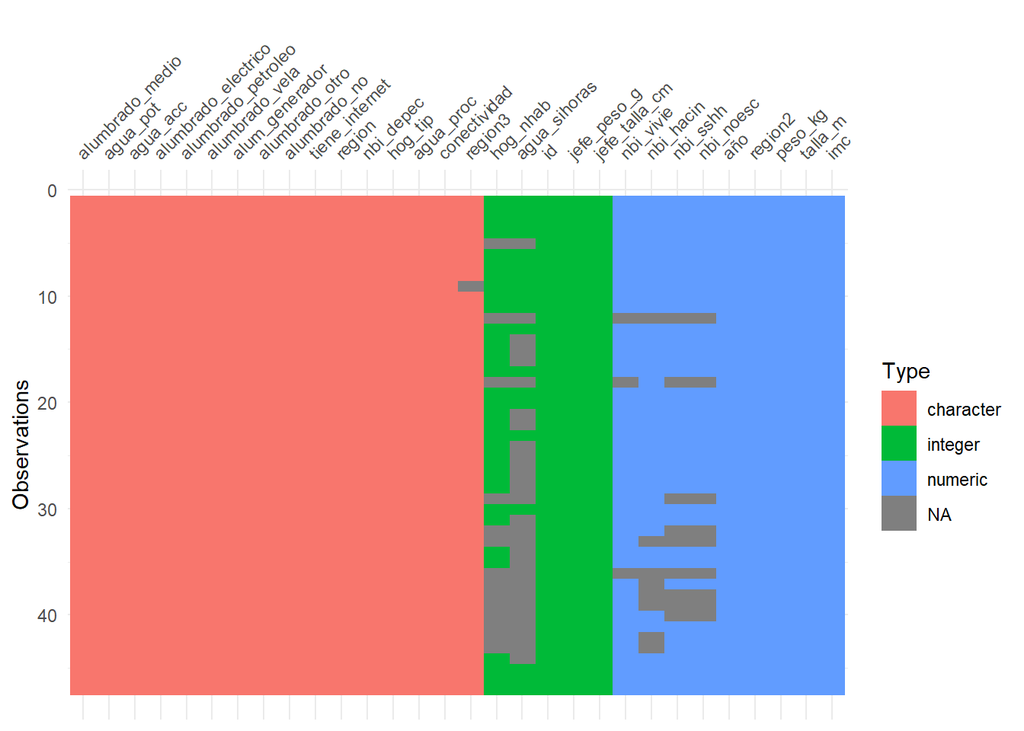

```r
data_clean %>%
  vis_dat()
```

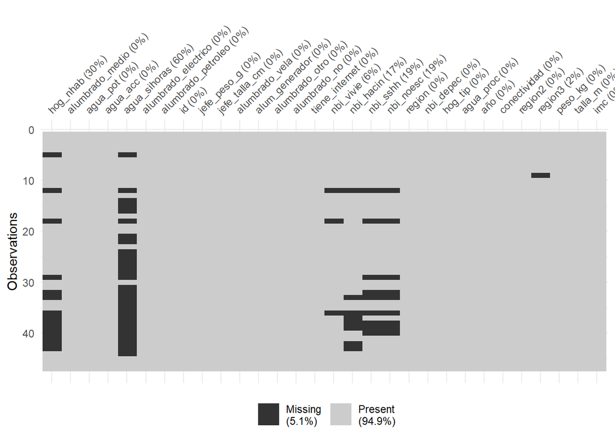

```r
data_clean %>%
  vis_miss()
```

### 5.5 Ejercicio 17

Evaluar si los datos perdidos de cada variable se relacionan o vinculan entre sí con el de otras variables

**Solución**

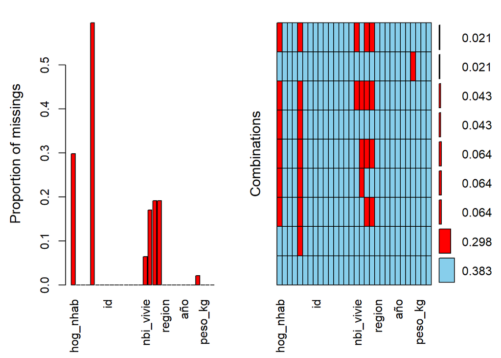

```r
data_clean %>%
  aggr(numbers = TRUE)
```

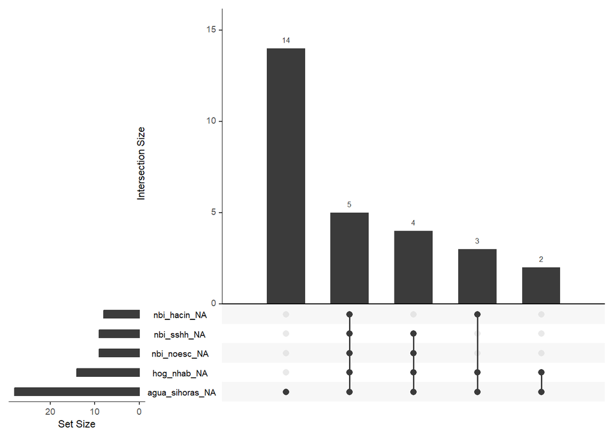

```r
data_clean %>%
  gg_miss_upset()
```